# R İle Zaman Serisi Analizi

## 5.1 Toplamsal Winters Yöntemi

Verilerin trend’den bağımsız ve mevsimsel hareketlerin büyüklüğünün zaman içinde sabit olduğu varsayılır.

### 5.1.1 α, β ve γ’nın Belirlenmesi:

Kurulan model toplamsal model olacağı için fonksiyon içindeki model değişkeni “AAA” olmalıdır.

```r
Winters1<- forecast::ets(veri_ts, model = "AAA")
summary(Winters1)
```

```
## ETS(A,A,A)
##
## Call:
##  forecast::ets(y = veri_ts, model = "AAA")
##
##   Smoothing parameters:
##     alpha = 0.35
##     beta  = 0.0015
##     gamma = 0.376
##
##   Initial states:
##     l = 142359.4408
##     b = 650.5006
##     s = -2003.421 -21271.04 -10677.56 13503.16 37439.09 33817.96
##            5562.078 -19450.16 -23820.27 -12164.33 -8641.028 7705.514
##
##   sigma:  7062.892
##
##      AIC     AICc      BIC
## 14164.62 14165.70 14239.00
##
## Training set error measures:
##                     ME     RMSE      MAE        MPE     MAPE      MASE
## Training set -443.1612 6965.969 5416.702 -0.2365098 2.209926 0.6997371
##                   ACF1
## Training set 0.3491801
```

**Model çıktısına bakıldığında:**

- l = 142359.4408 -> ortalama düzeyin başlangıç değeridir.
- b = 650.5006 -> eğimin başlangıç değeridir.
- s değerine bakıldığında ise 12 farklı değer (periyot sayımız 12 olduğu için) vardır. Bu değerler mevsimsel terimin başlangıç değerleridir. Başlangıç değerleri kullanılarak Optimal düzleştirme katsayıları,
  - α = 0.35
  - β = 0.0015
  - γ = 0.376 olarak elde edilmiştir.

#### Toplamsal Winters Modeli HKO

- Hata kareler ortalaması-HKO = 6965.969^2 bulunmuştur.

### 5.1.2 Tahmin, ACF ve Dağılım Grafikleri:

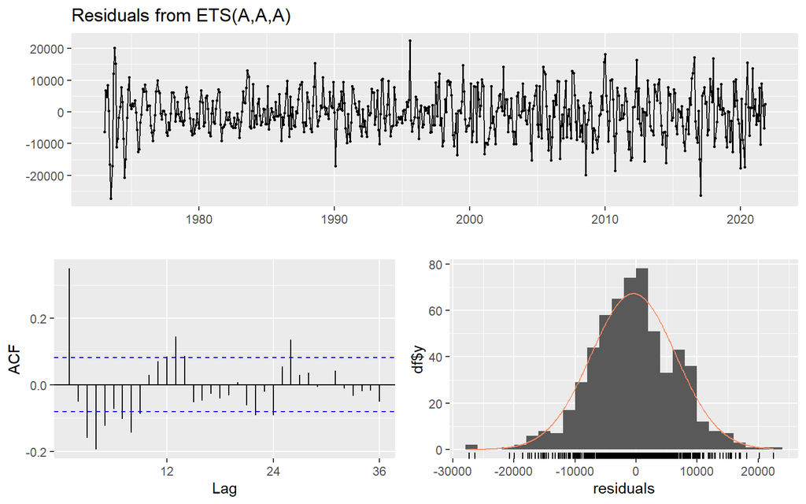

```
##
##  Ljung-Box test
##
## data:  Residuals from ETS(A,A,A)
## Q* = 225.17, df = 26, p-value < 2.2e-16
##
## Model df: 16.   Total lags used: 42
```

```r
library(forecast)
checkresiduals(Winters1, lag = 42)
```

### 5.1.3 Tahmin ve Hata Serilerinin Bulunması:

α, β ve γ düzleştirme katsayıları kullanılarak serinin tahmin değerleri aşağıdaki gibi bulunabilir.

```r
tahmin_win1<- Winters1[["fitted"]]
```

**Tahmin edilen ilk 12 değeri (2022 yılı ABD elektrik tüketim tahminlerini) görelim:**

```r
ongoru1 <- forecast(Winters1,h=12)
knitr::kable(ongoru1[["mean"]],col.names = "2022 yılı ABD elektrik tüketimi - Toplamsal Winters Tahminleri", align = "c")
```

| 2022 yılı ABD elektrik tüketimi - Toplamsal Winters Tahminleri |
| --- |
| 327234.9 |
| 337517.9 |
| 310134.8 |
| 309123.1 |
| 286408.9 |
| 305893.2 |
| 349325.4 |
| 393799.4 |
| 393737.8 |
| 348913.6 |
| 317616.4 |
| 300346.8 |

**Tahmin ve Orijinal serileri birlikte çizdirelim:**

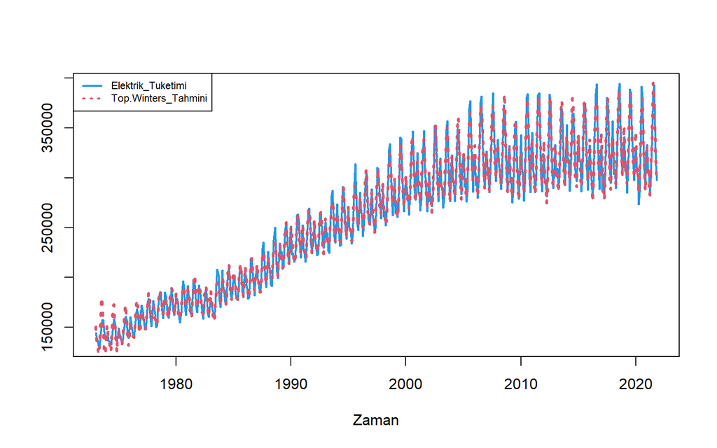

```r
plot( window(veri_ts),
      xlab="Zaman", ylab="",lty=1, col=4, lwd=2)
lines( window(tahmin_win1) ,lty=3,col=2,lwd=3)
legend("topleft",c(expression(paste(Elektrik_Tuketimi)),
               expression(paste(Top.Winters_Tahmini))),
       lwd=c(2,2),lty=c(1,3), cex=0.7, col=c(4,2))
```

**Zaman Serisi Grafiğine bakıldığında:**

- Tahmin ile orijinal seri arasında **uyum olduğu** görülmektedir. Yani görsel olarak Toplamsal Winters yöntemi ile yapılan tahminlerin gerçeğe yakın olduğunu söyleyebiliriz.
- Fakat emin olmak için hataların akgürültü olup olmadığına bakmamız gerekmektedir.

**Hata Serisi:**

> α, β ve γ düzleştirme katsayıları kullanılarak serinin hata değerleri aşağıdaki gibi bulunabilir.

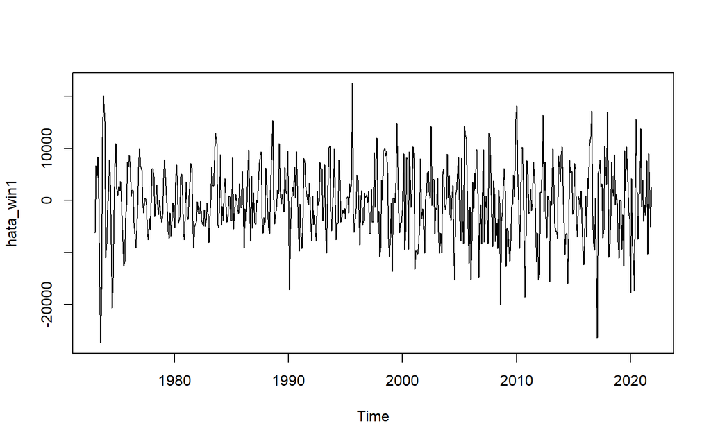

```r
hata_win1<- Winters1[["residuals"]]
plot.ts(hata_win1)
```

### Hatalar Akgürültü mü?

> > Ho: Hatalar Akgürültüdür.(Hatalar arasında ilişki yoktur.)  
> > H1: Hatalar Akgürültü değildir.(Hatalar arasında ilişki vardır.)

**Hatalar için ACF Grafiği:**

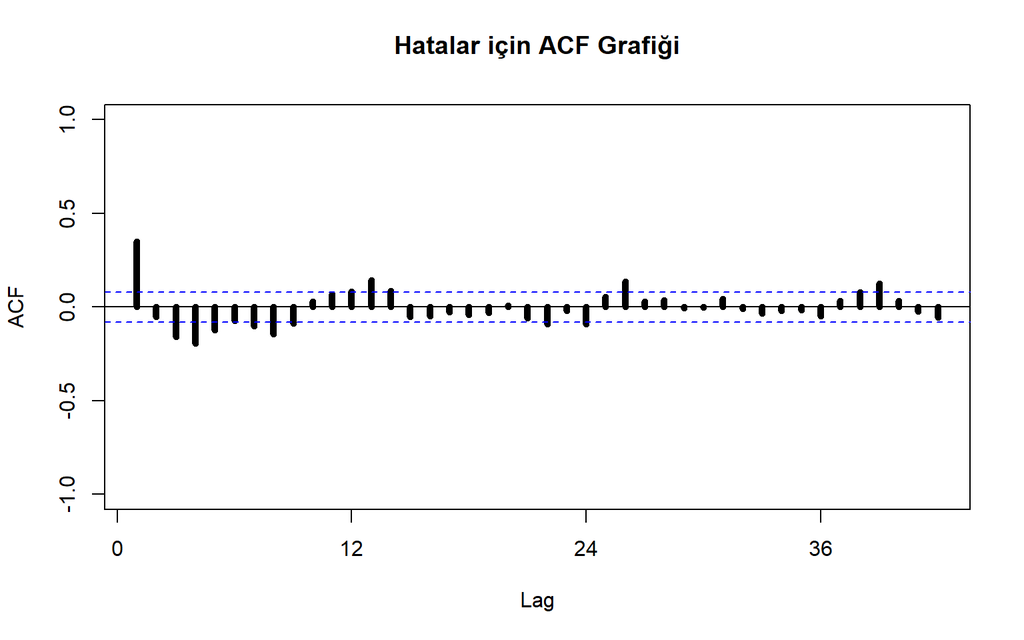

```r
Acf(hata_win1, lag.max = 42,  ylim=c(-1,1), lwd=5,main="Hatalar için ACF Grafiği")
```

### Toplamsal Winter Yöntemi ile elektrik Tüketim Öngörüsü Grafiği:

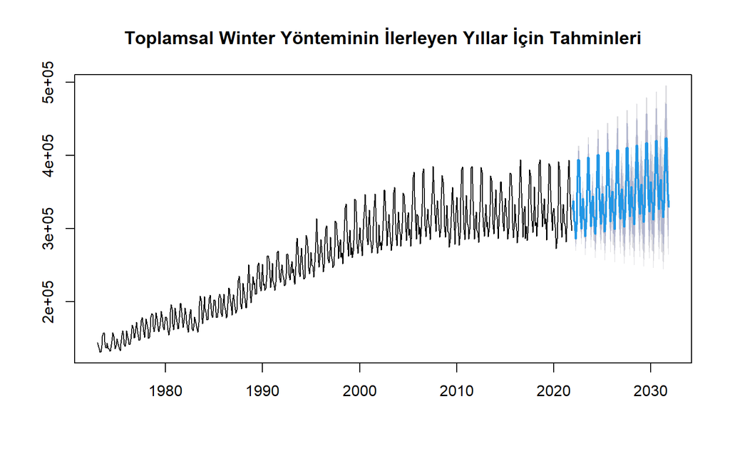

```r
plot(forecast(Winters1,h=120),main = "Toplamsal Winter Yönteminin İlerleyen Yıllar İçin Tahminleri")
```

## 5.2 Çarpımsal Winters Yöntemi

Mevsimsel hareketlerin trende bağlı olarak değiştiği ve trendin bir çarpanı olduğu varsayılmaktadır. Genellikle çarpımsal model tercih edilmektedir.

### 5.2.1 α, β ve γ’nın Belirlenmesi:

Kurulan model çarpımsal model olacağı için fonksiyon içindeki model değişkeni “MAM” olmalıdır.

```r
Winters2<- forecast::ets(veri_ts, model = "MAM")
summary(Winters2)
```

```
## ETS(M,A,M)
##
## Call:
##  forecast::ets(y = veri_ts, model = "MAM")
##
##   Smoothing parameters:
##     alpha = 0.3292
##     beta  = 9e-04
##     gamma = 0.2528
##
##   Initial states:
##     l = 141713.6213
##     b = 564.3679
##     s = 0.991 0.958 0.9931 1.0717 1.0836 1.0489
##            0.9816 0.9136 0.9304 0.9685 0.9911 1.0685
##
##   sigma:  0.0231
##
##      AIC     AICc      BIC
## 13919.11 13920.19 13993.49
##
## Training set error measures:
##                     ME     RMSE      MAE        MPE     MAPE      MASE
## Training set -378.7723 6176.062 4754.346 -0.2122225 1.822243 0.6141731
##                   ACF1
## Training set 0.3226722
```

**Model çıktısına bakıldığında:**

- l = 141713.6213 -> ortalama düzeyin başlangıç değeridir.
- b = 564.3679 -> eğimin başlangıç değeridir.
- s değerine bakıldığında ise 12 farklı değer (periyot sayımız 12 olduğu için) vardır. Bu değerler mevsimsel terimin başlangıç değerleridir. Başlangıç değerleri kullanılarak Optimal düzleştirme katsayıları,
  - α = 0.3292
  - β = 0
  - γ = 0.2528 olarak elde edilmiştir.

#### Çarpımsal Winters Modeli HKO

- Hata kareler ortalaması-HKO = 6176.062^2 bulunmuştur.

### 5.2.2 Tahmin, ACF ve Dağılım Grafikleri:

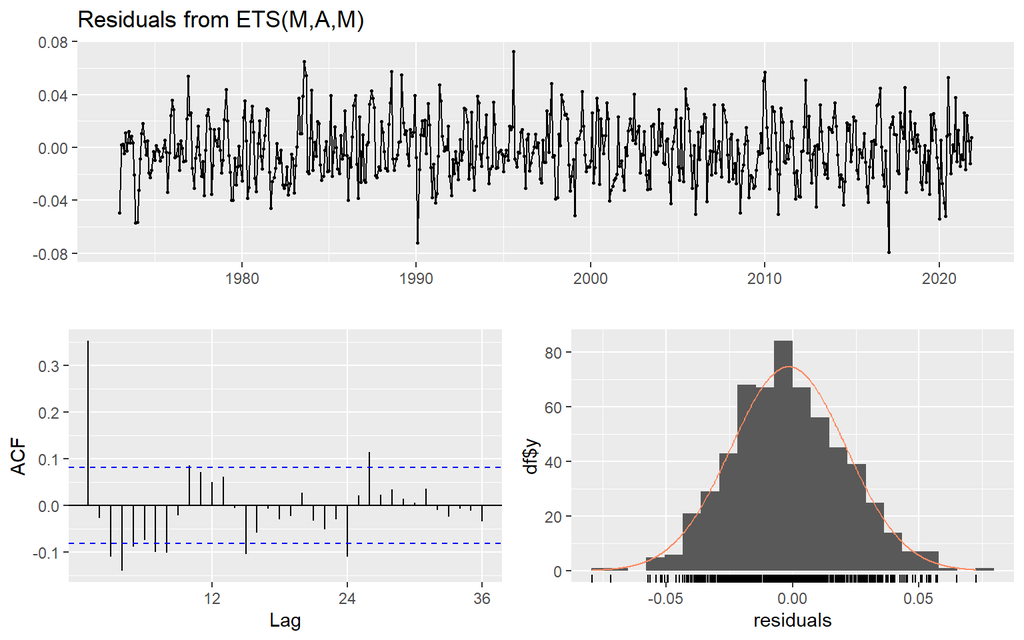

```
##
##  Ljung-Box test
##
## data:  Residuals from ETS(M,A,M)
## Q* = 169.05, df = 26, p-value < 2.2e-16
##
## Model df: 16.   Total lags used: 42
```

```r
library(forecast)
checkresiduals(Winters2, lag = 42)
```

### 5.2.3 Tahmin ve Hata Serilerinin Bulunması:

α, β ve γ düzleştirme katsayıları kullanılarak serinin tahmin değerleri aşağıdaki gibi bulunabilir.

```r
tahmin_win2<- Winters2[["fitted"]]
```

**Tahmin edilen ilk 12 değeri (2022 yılı ABD elektrik tüketim tahminlerini) görelim:**

```r
ongoru2 <- forecast(Winters2,h=12)
knitr::kable(ongoru2[["mean"]],col.names = "2022 yılı ABD elektrik tüketimi - Çarpımsal Winters Tahminleri", align = "c")
```

| 2022 yılı ABD elektrik tüketimi - Çarpımsal Winters Tahminleri |
| --- |
| 327095.8 |
| 340700.8 |
| 311116.3 |
| 311409.0 |
| 288255.3 |
| 307903.8 |
| 349996.3 |
| 395149.7 |
| 393769.1 |
| 349813.4 |
| 318125.3 |
| 300226.6 |

**Tahmin ve Orijinal serileri birlikte çizdirelim:**

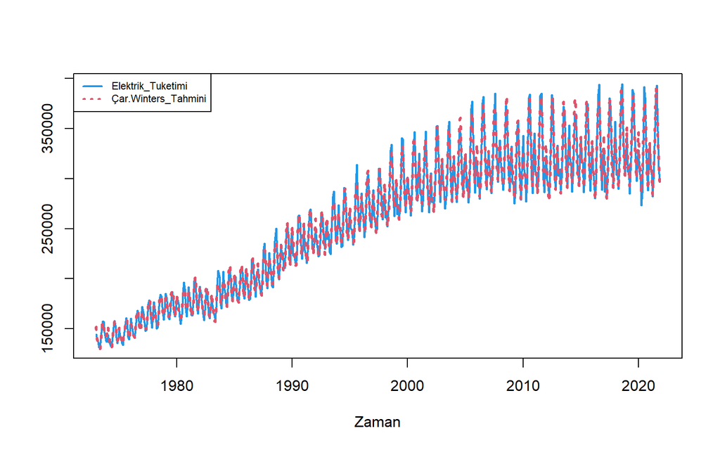

```r
plot( window(veri_ts),
      xlab="Zaman", ylab="",lty=1, col=4, lwd=2)
lines( window(tahmin_win2) ,lty=3,col=2,lwd=3)
legend("topleft",c(expression(paste(Elektrik_Tuketimi)),
               expression(paste(Çar.Winters_Tahmini))),
       lwd=c(2,2),lty=c(1,3), cex=0.7, col=c(4,2))
```

**Zaman Serisi Grafiğine bakıldığında:**

- Tahmin ile orijinal seri arasında **uyum olduğu** görülmektedir. Yani görsel olarak Çarpımsal Winters yöntemi ile yapılan tahminlerin gerçeğe yakın olduğunu söyleyebiliriz.
- Fakat emin olmak için hataların akgürültü olup olmadığına bakmamız gerekmektedir.

**Hata Serisi:**

> α, β ve γ düzleştirme katsayıları kullanılarak serinin hata değerleri aşağıdaki gibi bulunabilir.

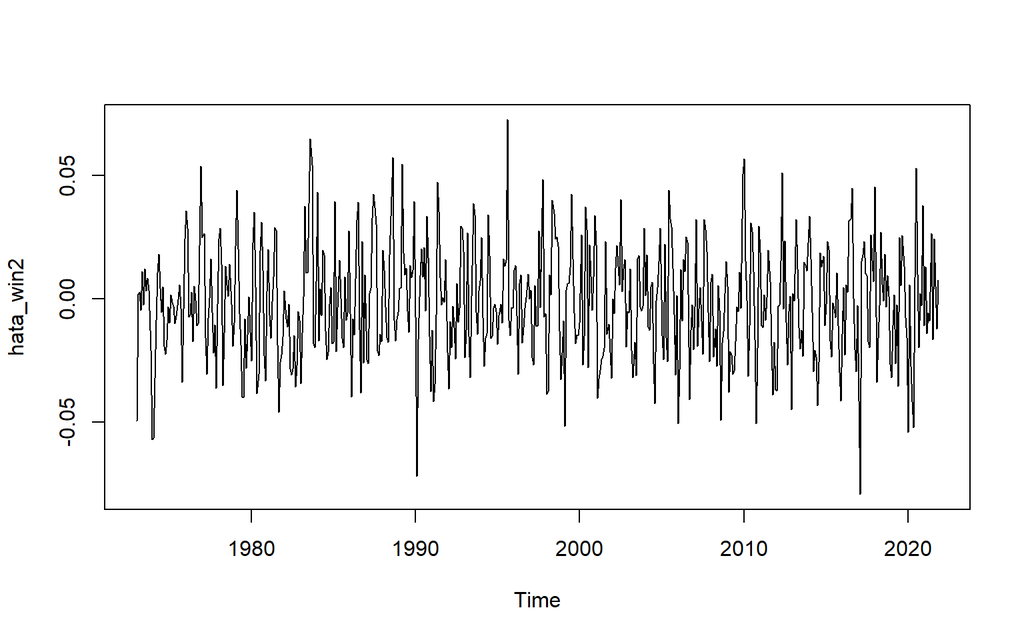

```r
hata_win2<- Winters2[["residuals"]]
plot.ts(hata_win2)
```

### Hatalar Akgürültü mü?

> > Ho: Hatalar Akgürültüdür.(Hatalar arasında ilişki yoktur.)  
> > H1: Hatalar Akgürültü değildir.(Hatalar arasında ilişki vardır.)

**Hatalar için ACF Grafiği:**

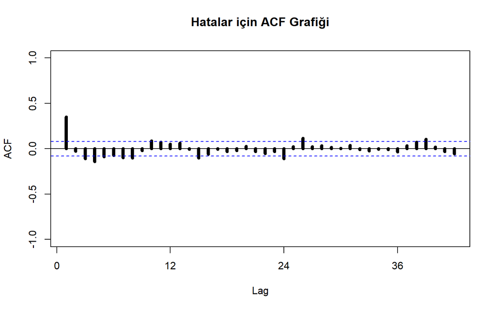

```r
Acf(hata_win2, lag.max = 42,  ylim=c(-1,1), lwd=5,main="Hatalar için ACF Grafiği")
```

### Çarpımsal Winter Yöntemi ile elektrik Tüketim Öngörüsü Grafiği:

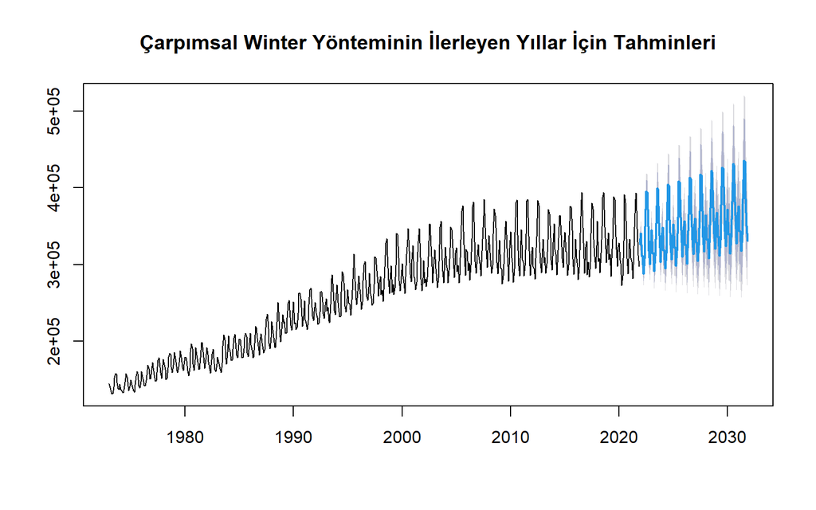

```r
plot(forecast(Winters2,h=120),main = "Çarpımsal Winter Yönteminin İlerleyen Yıllar İçin Tahminleri")
```

## 5.3 Peki hangi model daha iyi?

**Toplamsal ve Çarpımsal Winters 2022 Tahminleri:**

```r
ongoru2022 <- as.data.frame(cbind(ongoru1[["mean"]],ongoru2[["mean"]]))
colnames(ongoru2022) <- c("Toplamsal Winters", "Çarpımsal Winters")
knitr::kable(ongoru2022, align = "c")
```

| Toplamsal Winters | Çarpımsal Winters |
| --- | --- |
| 327234.9 | 327095.8 |
| 337517.9 | 340700.8 |
| 310134.8 | 311116.3 |
| 309123.1 | 311409.0 |
| 286408.9 | 288255.3 |
| 305893.2 | 307903.8 |
| 349325.4 | 349996.3 |
| 393799.4 | 395149.7 |
| 393737.8 | 393769.1 |
| 348913.6 | 349813.4 |
| 317616.4 | 318125.3 |
| 300346.8 | 300226.6 |

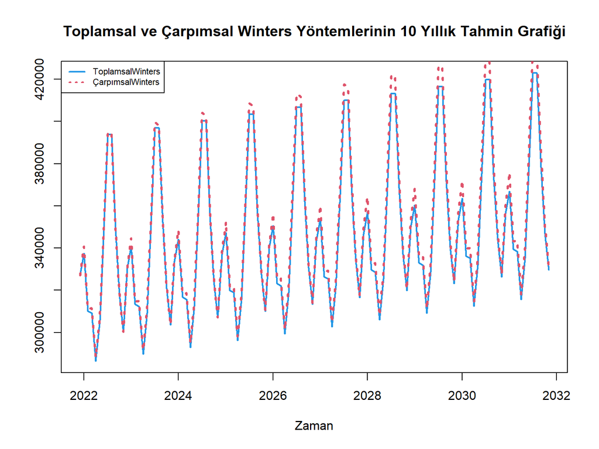

```r
ongoru111 <- forecast(Winters1,h=120)
ongoru222 <- forecast(Winters2,h=120)
plot( window(ongoru111[["mean"]]),
      xlab="Zaman", ylab="",lty=1, col=4, lwd=2,main = "Toplamsal ve Çarpımsal Winters Yöntemlerinin 10 Yıllık Tahmin Grafiği")
lines( window(ongoru222[["mean"]]) ,lty=3,col=2,lwd=3)
legend("topleft",c(expression(paste(ToplamsalWinters)),
               expression(paste(ÇarpımsalWinters))),
       lwd=c(2,2),lty=c(1,3), cex=0.7, col=c(4,2))
```

- İki modelin 2022 yılı elektrik kullanımı tahmin değerlerinin ve 10 yıllık Tahminlerinin yakın olduğunu söyleyebiliriz.

> Peki hangi model bu veri için daha iyi?

Bu durumda iki yöntemin de HKO (Hata Kareler Ortalaması) değerlerine bakmamız gerekir.

Toplamsal Winters Yöntemi HKO = 6965.969^2  
Çarpımsal Winters Yöntemi HKO = 6176.062^2

**Çarpımsal Winters yönteminin HKO’sı, Toplamsal Winters yönteminden küçük olduğu için; Çarpımsal Winters yöntemi seriyi tahmin etmek için daha uygun olan yöntemdir.**

## 5.Bölüm Özet

Bu bölümde; Mevsimsel seriler için kullanılan Üstel Düzleştirme yöntemleri ile ABD’deki aylık elektrik tüketimini tahmin etmeye çalıştık. Uyguladığımız iki model de veriyi tahmin etmede iyi sonuçlar verdi. Bu iki model arasında Hata Kareler Ortalaması daha küçük olan Çarpımsal Winters yönteminin daha iyi olduğu sonucuna vardık.

# BÖLÜM 6: BOX - JENKİNS MODELLERİ

> Box-Jenkins modelleri, geçen bölümde anlatılan üstel düzleştirme yöntemlerinin genelleştirilmiş biçimi olup mevsimsel ve mevsimsel olmayan modeller şeklinde ikiye ayrılmaktadır.

> Box-Jenkins Yöntemi, sırasıyla seriye uygun *modeli belirleme*, *modelin tahmini*, *tanısal denetimi* ve *öngörü* işllemlerini içermektedir. Bu işlemlerin yapılabilmesi için öncelikle serinin trentten ve mevsimsel dalgalanmadan arındırılınış olmasına, yani serinin **durağan** olmasına dikkat edilmelidir.  
> Durağan olan ya da durağan hale dönüştürülen serinin ACF ve PACF grafiklerine göre seriye uygun olabikecek model belirlenir. Bu belirleme işlemine göre, eğer ACF grafiğindeki ilişki miktarları gecikme sayısı arttıkça yavaş yavaş azalıyor, ama PACF grafiğinde bu azalma bir anda, yani hızlı bir şekilde oluyorsa seriye uygun model **otoregresyon** modeli olmaktadır. Bunun tam tersi, yani PACF grafiğindeki ilişki miktarları yavaş yavaş azalırken ACF grafiğindeki ilişki miktarları hızlı bir şekilde azalıyorsa model **hareketli ortalama** modeli olmaktadır. Hem ACF hem de PACF grafıklerinde ilişki miktarlarının azalışı yavaş yavaş olursa model **otoregresif hareketli ortalama** modeli olmaktadır.  
> Ancak, bu azalışların hızlı ya da yavaş olduğuna karar verebilmek oldukça güç olup doğru kararların verilebilmesi için de yılların deneyimi gerekmektedir. Bu nedenle, verilen kararın doğru olup olmadığını anlayabilmek için modeldeki katsayıların *önemlilik testi* sonucuna bakılmaktadır. ACF ve PACF grafıklerinden karar verilen modelin katsayılarından herhangi biri istatistiksel olarak önemsiz ise bu modelin seriye uygun olmadığı anlaşılır. Buradan, grafıklerin yanlış yorumlandığı ortaya çıkar.  
> Dolayısıyla, model belirleme işleminin devamı olarak modelin katsayılarının tahmini işlemi de önemli olmakta ve bu iki işlem birbirini tamamlamaktadır.

> > **Kaynak:** *Prof. Dr. Cem Kadılar, Dr. Hatice Öncel Çekim SPSS ve R Uygulamalı Zaman Serileri Analizine Giriş*

**Buradaki başlıkta; Trende sahip serinin birinci farkını aldığımızda serinin aynı zamanda mevsimselliğe sahip olduğunu ACF grafiğine bakarak açıklamıştık.**

> Kullandığımız veri mevsimselliğe sahip olduğu için bu bölümde sadece **Mevsimsel Box-Jenkins modelleri** gösterilecektir.

> **Mevsimsel Box-Jenkins modelleri üç farklı model barındırır. Bunlar;** - mevsimsel otoregresyon (SAR)  
> - mevsiınsel hareketli ortalama (SMA)  
> - mevsimsel otoregresif hareketli ortalama (SARMA) modelleridir.  
> Mevsimsel Box-Jenkins modelleri genelde ARIMA(p,d,q)(P,D,Q)s biçiminde ifade edilmektedir. Burada,  
> - p otoregresyon (AR) modelinin derecesi,  
> - d fark alma işlemi sayısı  
> - q hareketli ortalama (MA) modelinin derecesi  
> - P mevsimsel otoregresyon (SAR) modelinin derecesi,  
> - D mevsimsel fark alma işlemi sayısı,  
> - Q mevsimsel hareketli ortalama (SMA) modelinin derecesi  
> - s periyot  
> olmaktadır.

## Zaman Serisi Grafiğinin Çizilmesi

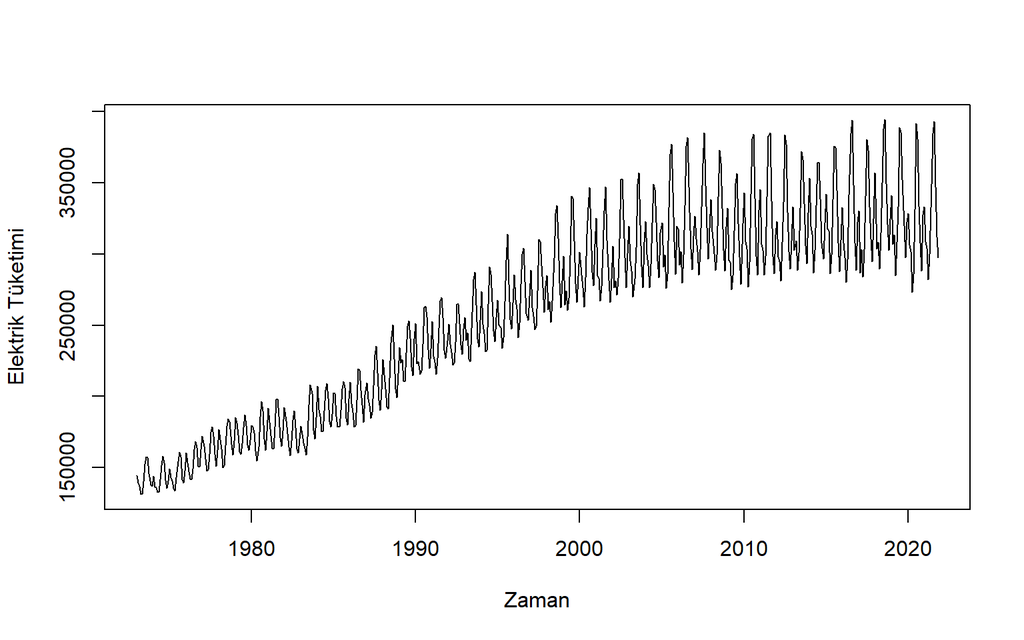

```r
ts.plot(veri_ts,gpars=list(xlab="Zaman", ylab="Elektrik Tüketimi"))
```

**Zaman Serisi Grafiğine bakıldığında:**

- Pozitif yönlü artış vardır. Bu yüzden Serinin artan bir **trende sahip** olduğunu söyleyebiliriz.
- Seride düzenli dalgalanmaların olduğu görülmektedir. Bu seride **mevsimsellik** olabileceğini gösterir. Daha kesin sonuç için ACF grafiğini çizelim.

## ACF ve PACF Grafiğinin Çizilmesi

> **Seride trendin olduğunu anlamak için ACF grafiğindeki ilk dört gecikmeye bakmak yeterlidir. İlk dört gecikme sınırlar dışındaysa seri için “trende sahiptir” diyebiliriz.**

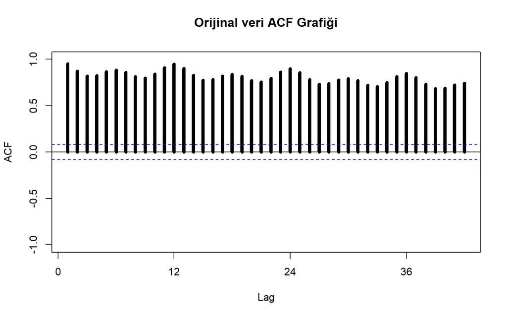

```r
library(fpp)
Acf(veri_ts,lag.max = 42,  ylim=c(-1,1), lwd=5,main="Orijinal veri ACF Grafiği")
```

**ACF Grafiğine bakıldığında:**

- Tüm gecikmeler (4 gecikme olması yeterlidir) sınırlar dışında olduğu için zaman serisinin **trende sahip** olduğu söylenebilir. Bu yüzden serinin farkı alınıp durağan hale getirilmelidir.
- Trend ile birlikte düzenli dalgalanmaların olduğu gözükse de baskın bir mevsimsellikten şu an için bahsedemeyiz.

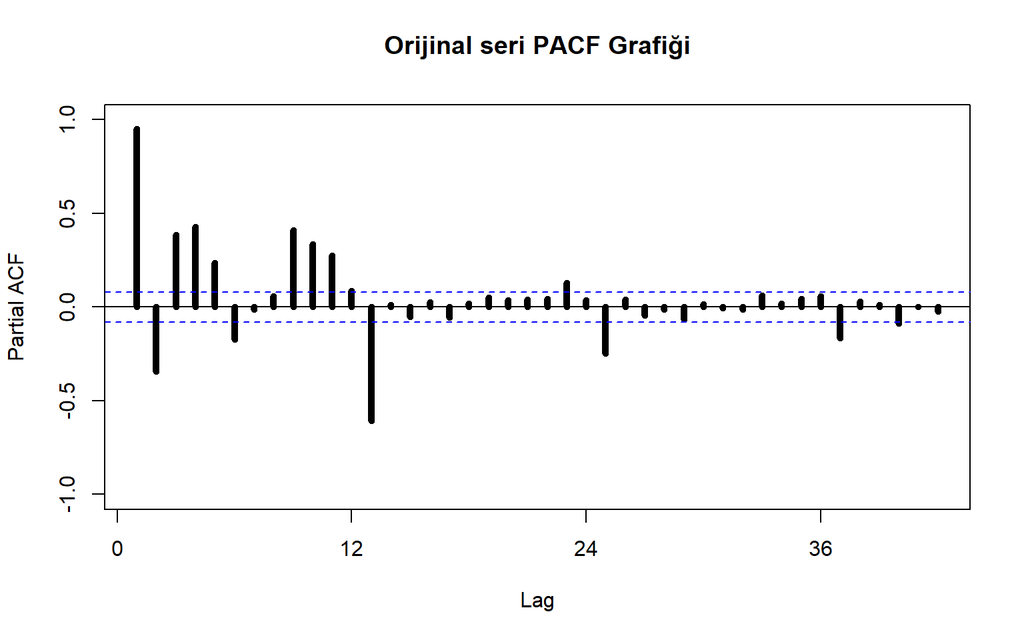

```r
Pacf(veri_ts,lag.max = 42,  ylim=c(-1,1), lwd=5,main="Orijinal seri PACF Grafiği")
```

## Birinci Farkın Alınması

```r
veri_birinci_fark <- diff(veri_ts, differences = 1)
```

## Farkı alınmış seri için ACF ve PACF:

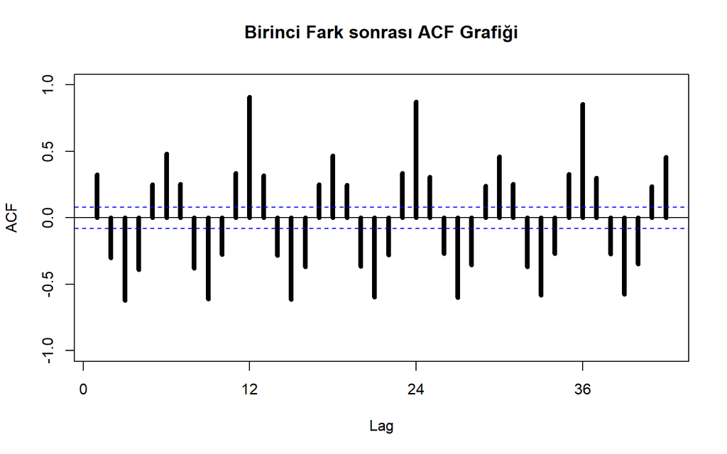

```r
Acf(veri_birinci_fark,lag.max = 42,  ylim=c(-1,1), lwd=5,main="Birinci Fark sonrası ACF Grafiği")
```

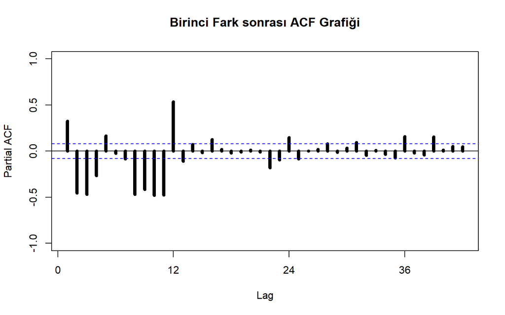

```r
Pacf(veri_birinci_fark,lag.max = 42,  ylim=c(-1,1), lwd=5,main="Birinci Fark sonrası ACF Grafiği")
```

**Birinci Farkı alınmış seri için ACF Grafiğine bakıldığında:**

- Yine tüm gecikmeler sınırlar dışında olduğu için birinci farkı alınmış zaman serisinin de trende sahip olduğu söylenebilir. Fakat bir öncekine göre bu ACF grafiğinde baskın bir **mevsimsellik** görülüyor. Dalgalanmalar ve gecikmelerdeki düzenli sıçramalar bunu destekliyor.

###Birinci Mevsimsel Farkın Alınması

```r
veri_ts_mev1 <- diff(veri_birinci_fark,12)
```

## Mevsimsel Farkı alınmış seri için ACF ve PACF:

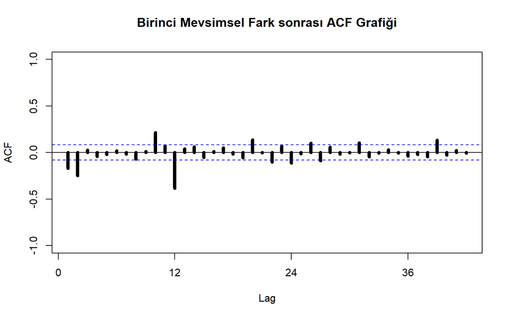

```r
Acf(veri_ts_mev1,lag.max = 42,  ylim=c(-1,1), lwd=5,main="Birinci Mevsimsel Fark sonrası ACF Grafiği")
```

**Birinci Mevsimsel Farkı alınmış seri için ACF Grafiğine bakıldığında:**

- İlk dört gecikmeden sadece iki tanesi sınırları geçtiği için **trendin kaybolduğunu** söyleyebiliriz.
- Düzenli dalgalanmaların dolayısıyla **mevsimselliğin de kaybolduğunu** söyleyebiliriz. >Seriyi durağan hale getirmek için;
- Bir kez fark aldığımız için -> **d=1**
- Bir kez mevsimsel fark adlığımız için -> **D=1**

## Durağan Serinin ACF ve PACF Yorumu:

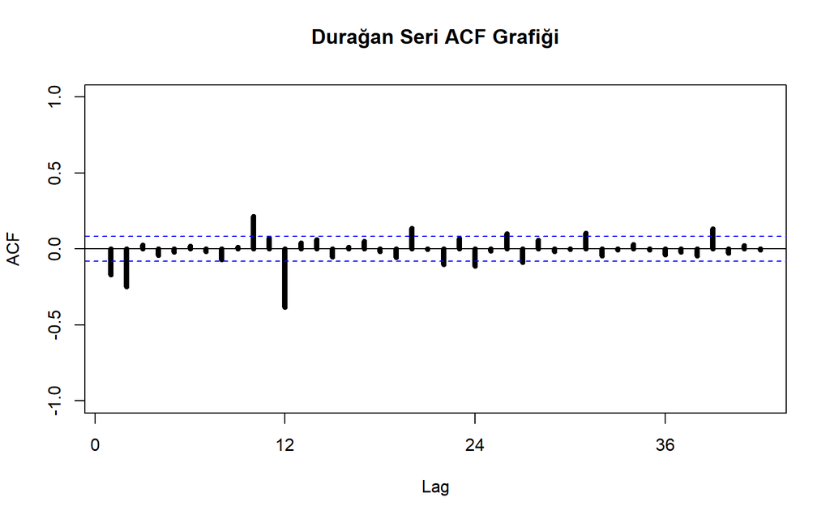

```r
Acf(veri_ts_mev1,lag.max = 42,  ylim=c(-1,1), lwd=5,main="Durağan Seri ACF Grafiği")
```

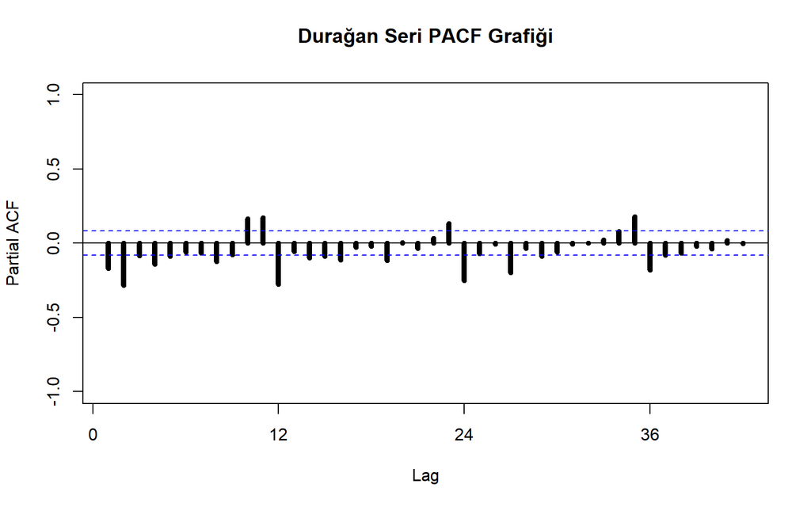

```r
Pacf(veri_ts_mev1,lag.max = 42,  ylim=c(-1,1), lwd=5,main="Durağan Seri PACF Grafiği")
```

**Durağan hale gelmiş serinin ACF ve PACF Grafiklerine bakıldığında:**

- ACF deki düşüşün daha sert olduğu söylenebilir. (ilk iki gecikmeler nerdeyse aynı seviyede. üçüncü gecikmelere bakıldığında ACF’deki gecikme PACF’ye göre daha fazladır.)
- Fakat bu yorum kesin ve belirgin bir yorum değildir. Grafiklere bakarak modeli anlayabilmek çok zordur. **Bu yüzden en iyi modeli bulmak için auto.arima() fonksiyonu kullanılacaktır.**

> auto.arima() fonksiyonunun sağlıklı çalışabilmesi için parmatrelerin doğru verilmesi gerekmektedir.

**Bu değerler ile en iyi modelin kodlarını yazalım:**

## En İyi SARIMA Modelinin Bulunması

```r
library(forecast)
en_iyi_model <- auto.arima(veri_ts,max.p = 2,max.q = 2,max.P = 3,max.Q = 3,d=1,D=1,seasonal = TRUE,ic = 'aicc')
summary(en_iyi_model)
```

```
## Series: veri_ts
## ARIMA(2,1,1)(0,1,1)[12]
##
## Coefficients:
##          ar1      ar2      ma1     sma1
##       0.6168  -0.0656  -0.9291  -0.7128
## s.e.  0.0485   0.0466   0.0274   0.0261
##
## sigma^2 = 35020961:  log likelihood = -5803.15
## AIC=11616.3   AICc=11616.41   BIC=11638.07
##
## Training set error measures:
##                     ME     RMSE      MAE         MPE     MAPE      MASE
## Training set -101.9441 5831.529 4476.961 -0.05593736 1.694013 0.5783401
##                      ACF1
## Training set 0.0009559872
```

## En iyi Modelin Tahmin, Hata ve Öngörüleri:

### Tahmin:

```r
tahmin21<- en_iyi_model[["fitted"]]
```

### Hata:

```r
hata21<- en_iyi_model[["residuals"]]
```

### Tahmin ve Orijinal Serinin Birlikte Çizilmesi:

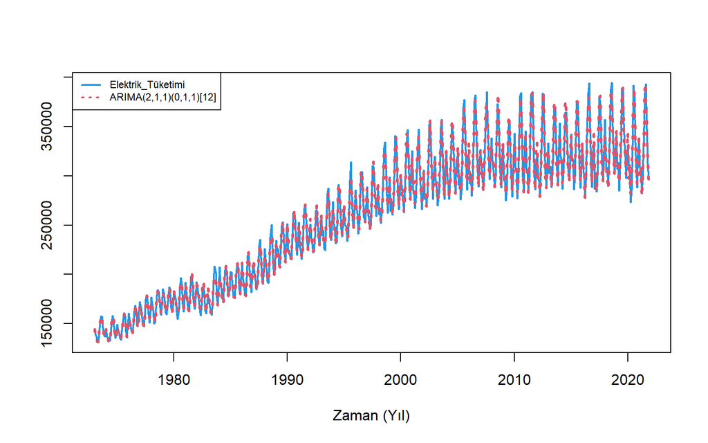

```r
plot( window(veri_ts),
      xlab="Zaman (Yıl)", ylab="",lty=1, col=4, lwd=2)
lines( window(tahmin21) ,lty=3,col=2,lwd=3)
legend("topleft",c(expression(paste(Elektrik_Tüketimi)),
               expression(paste("ARIMA(2,1,1)(0,1,1)[12]"))),
       lwd=c(2,2),lty=c(1,3), cex=0.7, col=c(4,2))
```

**Zaman Serisi Grafiğine bakıldığında:**

- Tahmin ile orijinal seri arasında **uyum olduğu** görülmektedir. Yani görsel olarak Box-Jenkins yöntemi ile kurulan modelin tahminlerinin gerçeğe yakın olduğunu söyleyebiliriz.
- Fakat emin olmak için hataların akgürültü olup olmadığına bakmamız gerekmektedir.

### Hatalar Akgürültü mü?

> > Ho: Hatalar Akgürültüdür.(Hatalar arasında ilişki yoktur.)  
> > H1: Hatalar Akgürültü değildir.(Hatalar arasında ilişki vardır.)

**Hatalar için ACF Grafiği:**

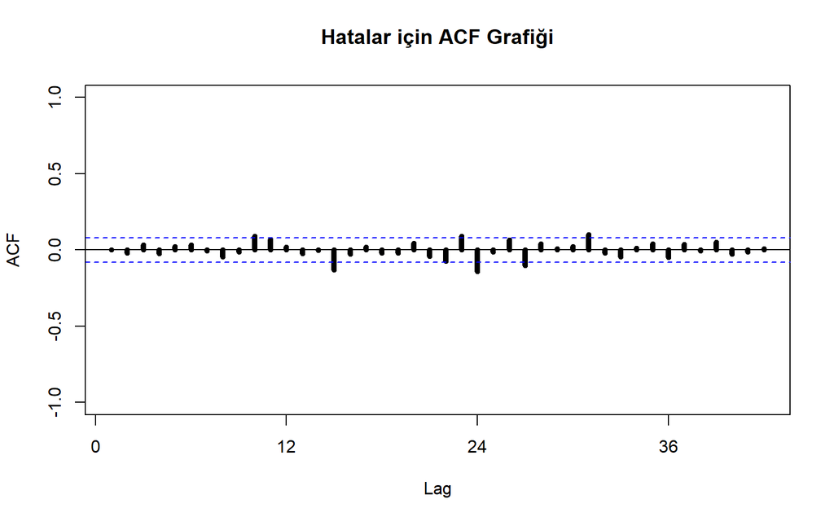

```r
Acf(hata21, lag.max = 42,  ylim=c(-1,1), lwd=5,main="Hatalar için ACF Grafiği")
```

**Hatalar için ACF Grafiğine bakıldığında:**

- İlk dört gecikmenin de sınırlar içinde kaldığı görülmektedir.
- Hataların akgürültü olduğunu söyleyebiliriz. Yani Hatalar arasında ilişki yoktur. Kurulan model tahmin etmede kullanılabilir.

### ARIMA Modeli ile 2022 yılının elektrik Tüketim Öngörüsü:

```r
ongoru21<- forecast(en_iyi_model, h=12)
knitr::kable(ongoru21[["mean"]],col.names = "ARIMA(2,1,1)(0,1,1)[12] Modelinin 2022 için aylık Elektrik Tüketim Tahminleri",align = "c")
```

| ARIMA(2,1,1)(0,1,1)[12] Modelinin 2022 için aylık Elektrik Tüketim Tahminleri |
| --- |
| 327038.8 |
| 339054.7 |
| 308118.3 |
| 307515.3 |
| 283593.8 |
| 301561.5 |
| 342029.5 |
| 386849.5 |
| 387040.2 |
| 344870.4 |
| 313781.8 |
| 296237.2 |

### ARIMA Modeli ile elektrik Tüketim Öngörüsü:

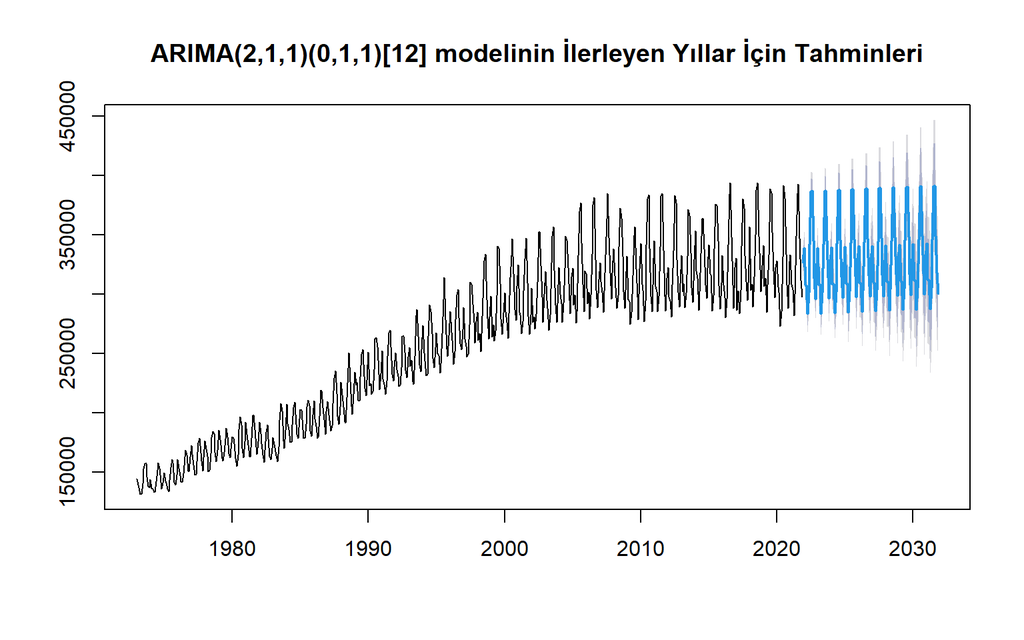

```r
plot(forecast(en_iyi_model,h=120),main = "ARIMA(2,1,1)(0,1,1)[12] modelinin İlerleyen Yıllar İçin Tahminleri")
```

## 6.Bölüm Özet

Bu bölümde; Box-Jenkins modelleri ile ABD’deki aylık elektrik tüketimini tahmin etmeye çalıştık. Fonksiyon yardımı ile bulduğumuz en iyi model veriyi tahmin etmede iyi sonuçlar verdi.

Sonuç olarak ABD’deki aylık elektrik tüketimi serisinin tahmini için Box-Jenkins modelleri uygundur ve kullanılabilir.

#### Veri ve Script dosyası için: [GİTHUB REPO](https://github.com/gungorrbaris/TR-time.series.analysis-R)

[Linkedin](https://www.linkedin.com/in/baris-gungor/)

[Github](http://www.github.com/gungorrbaris)